# Research Guide

## Logical

#### F9_05_UBIZ_IMCOME_OVER_LIMIT_X

UBI over filing threshold

DATA TYPEboolean

MAX NCHAR1

DESCRIPTIONWhether unrelated business income exceeded the $1,000 filing threshold.

**PREVIEW**:

```
N · Y
```

**PROPERTIES**:

| STAT | VAL | PER |
| --- | --- | --- |
| Rows | 25,000 |  |
| Distinct | 2 | (0.0%) |

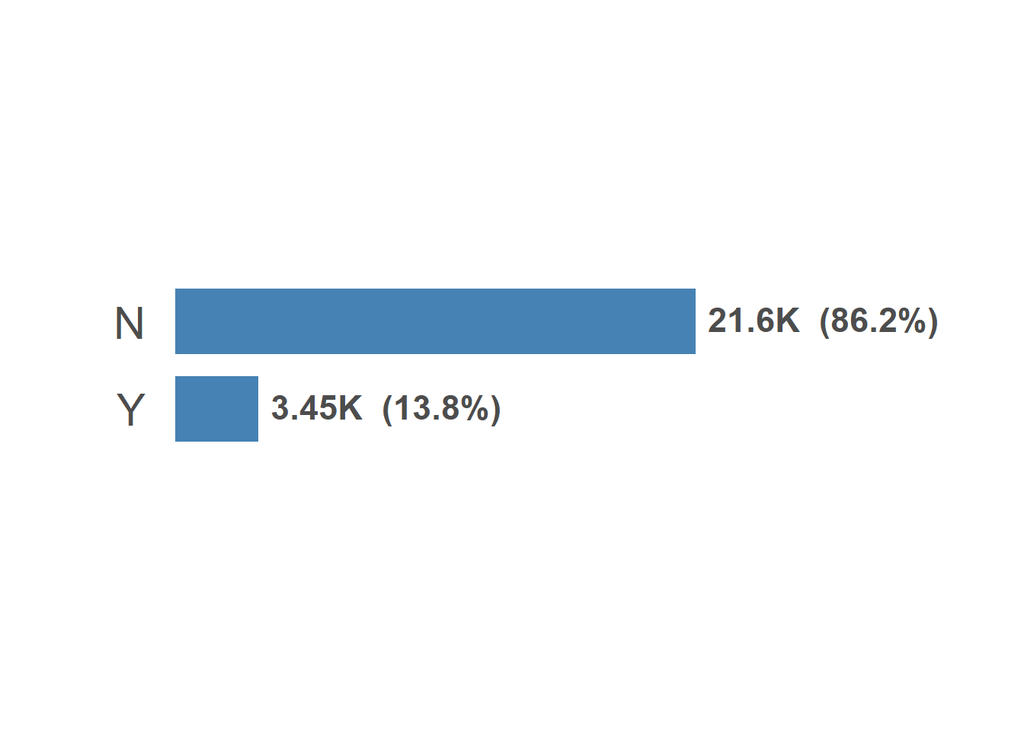

**CATEGORY LABELS**:

| N | Y |
| --- | --- |
| No | Yes |

#### OUTNCCS

In / out of NCCS core

DATA TYPEboolean

MAX NCHAR3

DESCRIPTIONWhether the organization is included in the NCCS core file.

**PREVIEW**:

```
IN · OUT
```

**PROPERTIES**:

| STAT | VAL | PER |
| --- | --- | --- |
| Rows | 25,000 |  |
| Distinct | 3 | (0.0%) |
| Missing/NA | 2,361 | (9.4%) |

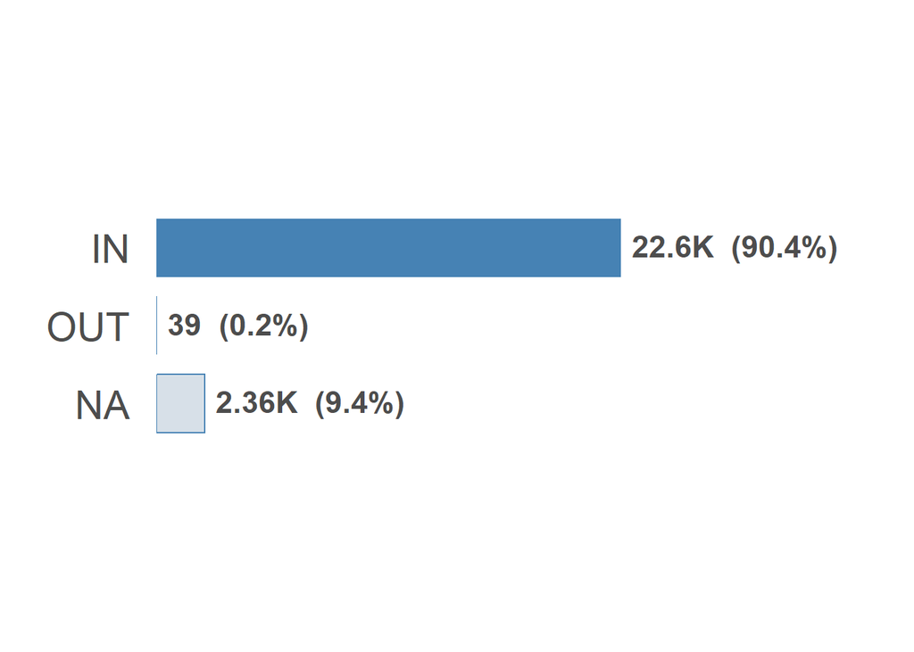

**CATEGORY LABELS**:

| IN | OUT |
| --- | --- |
| In NCCS core file | Out of NCCS core file |

## Factor

#### SUBSECCD

IRS subsection code

DATA TYPEcategorical

SUBTYPEnominal

CLASSadministrative_code

FORMATcode

MAX NCHAR2

DESCRIPTION501(c) subsection under which the organization is tax-exempt.

**PREVIEW**:

```
6 · 4 · 7 · 5 · 8 · 19 · 9 · 12 · 13 · 2 · 10 · 14 · 25 · 15 · 17
23 · 11 · 26 · 16 · 18 · 24 · 27 · 29
```

**PROPERTIES**:

| STAT | VAL | PER |
| --- | --- | --- |
| Rows | 25,000 |  |
| Distinct | 23 | (0.1%) |

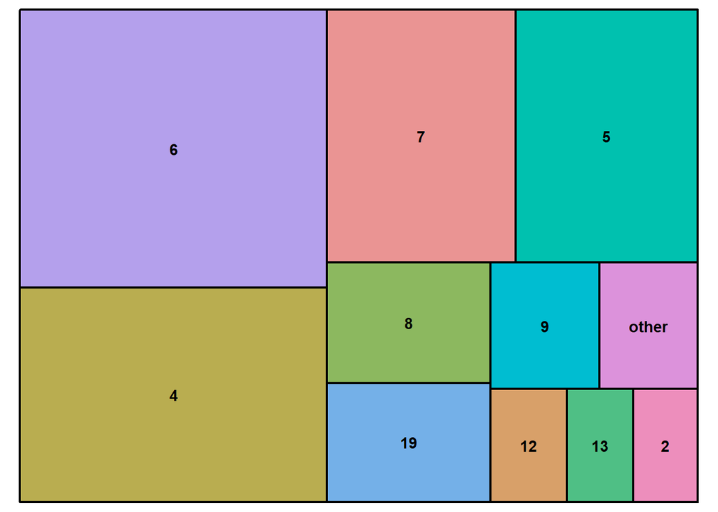

**FACTOR LEVELS**:

| Frequency | (%) | Label | Meaning |
| --- | --- | --- | --- |
| 6,391 | (25.6%) | 6 | 501(c)(6) Business league |
| 4,936 | (19.7%) | 4 | 501(c)(4) Social welfare organization |
| 3,571 | (14.3%) | 7 | 501(c)(7) Social & recreational club |
| 3,449 | (13.8%) | 5 | 501(c)(5) Labor / agricultural org |
| 1,479 | (5.9%) | 8 | 501(c)(8) Fraternal beneficiary society |
| 1,459 | (5.8%) | 19 | 501(c)(19) Veterans’ organization |
| 1,033 | (4.1%) | 9 | 501(c)(9) Voluntary employees’ beneficiary assoc. |
| 642 | (2.6%) | 12 | 501(c)(12) Benevolent life insurance / utility co-op |
| 561 | (2.2%) | 13 | 501(c)(13) Cemetery company |
| 545 | (2.2%) | 2 | 501(c)(2) Title-holding corporation |
| 466 | (1.9%) | 10 | 501(c)(10) Domestic fraternal society |
| 311 | (1.2%) | 14 | 501(c)(14) State-chartered credit union |
| 88 | (0.4%) | 25 | 501(c)(25) Title-holding corp (multiple parents) |
| 32 | (0.1%) | 15 | 501(c)(15) Mutual insurance company |
| 22 | (0.1%) | 17 | 501(c)(17) Supplemental unemployment benefit trust |
| 6 | (0.0%) | 23 | 501(c)(23) Veterans’ association |
| 2 | (0.0%) | 11 | 501(c)(11) Teachers’ retirement fund |
| 2 | (0.0%) | 26 | 501(c)(26) State high-risk health coverage org |
| 1 | (0.0%) | 16 | 501(c)(16) Crop-financing corporation |
| 1 | (0.0%) | 18 | 501(c)(18) Employee-funded pension trust |
| 1 | (0.0%) | 24 | 501(c)(24) Section 4049 ERISA trust |
| 1 | (0.0%) | 27 | 501(c)(27) State workers’ comp reinsurance org |
| 1 | (0.0%) | 29 | 501(c)(29) Qualified nonprofit health insurer (CO-OP) |

#### NTMAJ12

NTEE major group (12-category)

DATA TYPEcategorical

SUBTYPEnominal

CLASSclassification_code

FORMATcode

MAX NCHAR2

DESCRIPTIONNCCS 12-category summary of the organization’s NTEE classification.

**PREVIEW**:

```
PU · HU · MU · ED · UN · HE · AR · EN · IN · EH · RE · BH
```

**PROPERTIES**:

| STAT | VAL | PER |
| --- | --- | --- |
| Rows | 25,000 |  |
| Distinct | 12 | (0.0%) |

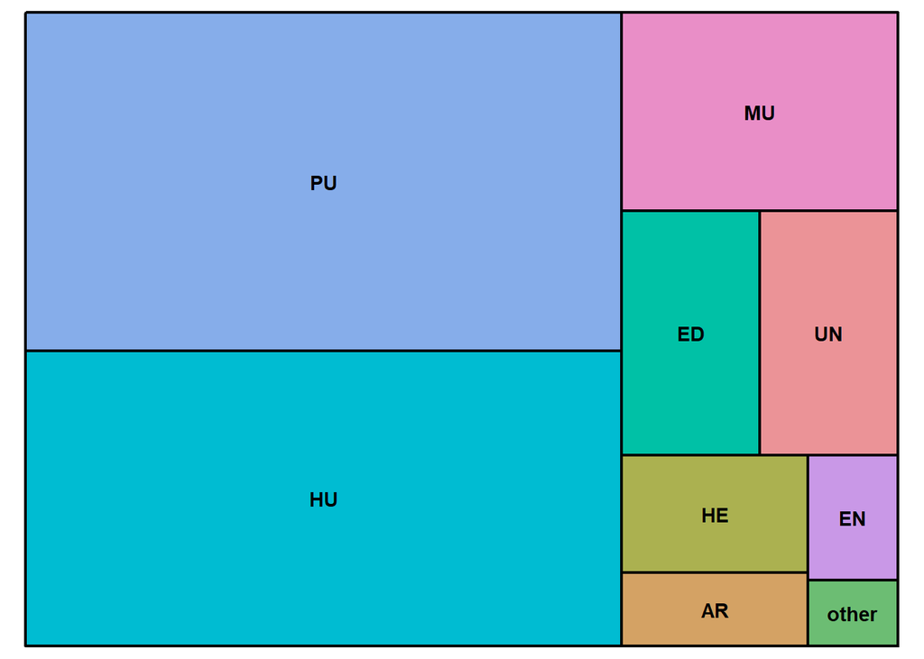

**FACTOR LEVELS**:

| Frequency | (%) | Label | Meaning |
| --- | --- | --- | --- |
| 9,128 | (36.5%) | PU | Public & societal benefit |
| 7,955 | (31.8%) | HU | Human services |
| 2,480 | (9.9%) | MU | Mutual / membership benefit |
| 1,528 | (6.1%) | ED | Education (excl. higher ed) |
| 1,524 | (6.1%) | UN | Unknown / unclassified |
| 994 | (4.0%) | HE | Health (excl. hospitals) |
| 615 | (2.5%) | AR | Arts, culture & humanities |
| 508 | (2.0%) | EN | Environment & animals |
| 101 | (0.4%) | IN | International & foreign affairs |
| 79 | (0.3%) | EH | Hospitals & primary care |
| 64 | (0.3%) | RE | Religion-related |
| 24 | (0.1%) | BH | Higher education |

#### NTEE1

NTEE major group

DATA TYPEcategorical

SUBTYPEnominal

CLASSclassification_code

FORMATcode

MAX NCHAR1

DESCRIPTIONFirst letter of the National Taxonomy of Exempt Entities code - the broad activity area.

**PREVIEW**:

```
S · N · W · Y · J · B · M · L · A · K · E · I · G · C · P · D · U
R · T · F · Q · O · X · Z · H · V
```

**PROPERTIES**:

| STAT | VAL | PER |
| --- | --- | --- |
| Rows | 25,000 |  |
| Distinct | 27 | (0.1%) |
| Missing/NA | 1,497 | (6.0%) |

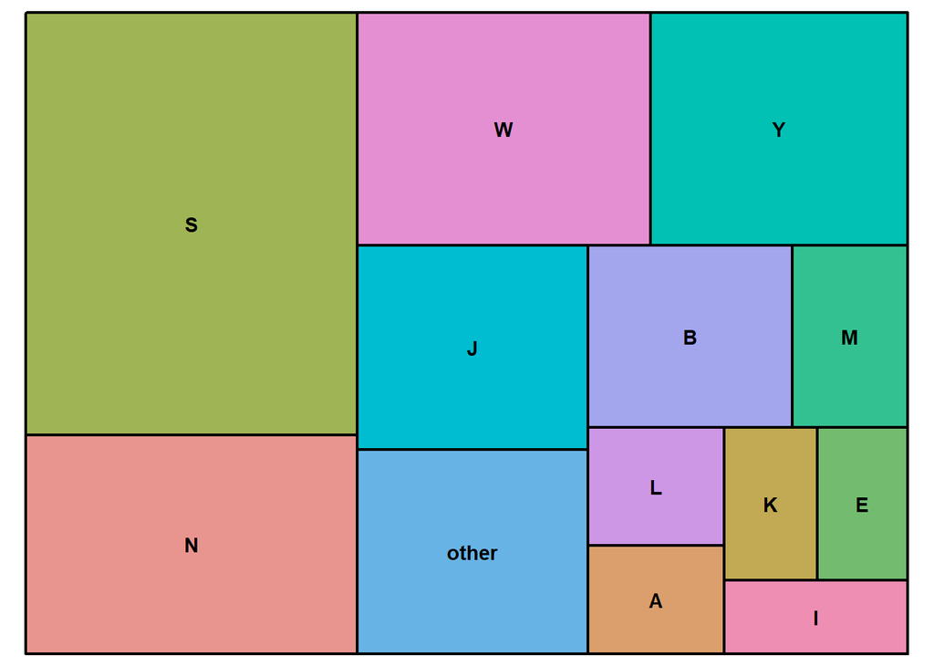

**FACTOR LEVELS**:

| Frequency | (%) | Label | Meaning |
| --- | --- | --- | --- |
| 5,817 | (23.3%) | S | Community Improvement |
| 3,018 | (12.1%) | N | Recreation & Sports |
| 2,835 | (11.3%) | W | Public & Societal Benefit |
| 2,480 | (9.9%) | Y | Mutual & Membership Benefit |
| 1,961 | (7.8%) | J | Employment |
| 1,552 | (6.2%) | B | Education |
| 876 | (3.5%) | M | Public Safety & Disaster Relief |
| 669 | (2.7%) | L | Housing & Shelter |
| 615 | (2.5%) | A | Arts, Culture & Humanities |
| 590 | (2.4%) | K | Food, Agriculture & Nutrition |
| 574 | (2.3%) | E | Health Care |
| 557 | (2.2%) | I | Crime & Legal-Related |
| 382 | (1.5%) | G | Voluntary Health Associations |
| 338 | (1.4%) | C | Environmental Quality |
| 210 | (0.8%) | P | Human Services |
| 170 | (0.7%) | D | Animal-Related |
| 166 | (0.7%) | U | Science & Technology |
| 164 | (0.7%) | R | Civil Rights & Advocacy |
| 142 | (0.6%) | T | Philanthropy & Grantmaking |
| 103 | (0.4%) | F | Mental Health & Crisis Intervention |
| 101 | (0.4%) | Q | International & Foreign Affairs |
| 74 | (0.3%) | O | Youth Development |
| 64 | (0.3%) | X | Religion-Related |
| 27 | (0.1%) | Z | Unknown |
| 14 | (0.1%) | H | Medical Research |
| 4 | (0.0%) | V | Social Science |

#### NTEESRC

NTEE source

DATA TYPEcategorical

SUBTYPEnominal

CLASScategory

FORMATcode

MAX NCHAR4

DESCRIPTIONMethod or source by which the NTEE code was assigned.

**PREVIEW**:

```
BEST · WORD · NEW · IRS · SOI · ZZ · SUB · SUB2 · SUB3 · ACT1 · VER
ntCO · HIED · END2 · thp
```

**PROPERTIES**:

| STAT | VAL | PER |
| --- | --- | --- |
| Rows | 25,000 |  |
| Distinct | 16 | (0.1%) |
| Missing/NA | 1,378 | (5.5%) |

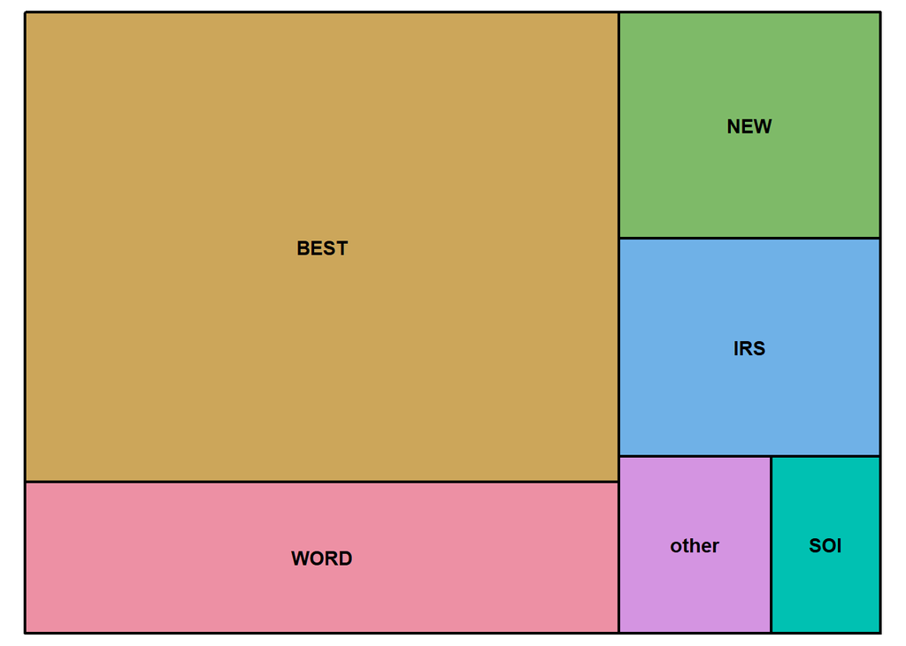

**FACTOR LEVELS**:

| Frequency | (%) | Label | Meaning |
| --- | --- | --- | --- |
| 12,410 | (49.6%) | BEST | Best available assignment |
| 4,000 | (16.0%) | WORD | Keyword / text-based |
| 2,621 | (10.5%) | NEW | Newly assigned |
| 2,540 | (10.2%) | IRS | IRS-assigned |
| 855 | (3.4%) | SOI | IRS Statistics of Income |
| 454 | (1.8%) | ZZ | Unassigned |
| 306 | (1.2%) | SUB | Subsector reassignment |
| 140 | (0.6%) | SUB2 | Subsector reassignment (2nd pass) |
| 86 | (0.3%) | SUB3 | Subsector reassignment (3rd pass) |
| 84 | (0.3%) | ACT1 | Assigned from activity code |
| 48 | (0.2%) | VER | Manually verified |
| 46 | (0.2%) | ntCO | NCCS core assignment |
| 19 | (0.1%) | HIED | Higher-education override |
| 11 | (0.0%) | END2 | End-of-process assignment |
| 2 | (0.0%) | thp | Third-party source |

#### DEDUCTCD

Deductibility code

DATA TYPEcategorical

SUBTYPEnominal

CLASSadministrative_code

FORMATcode

MAX NCHAR1

DESCRIPTIONWhether contributions to the organization are tax-deductible.

**PREVIEW**:

```
2 · 1 · 0 · 4
```

**PROPERTIES**:

| STAT | VAL | PER |
| --- | --- | --- |
| Rows | 25,000 |  |
| Distinct | 5 | (0.0%) |
| Missing/NA | 1,887 | (7.5%) |

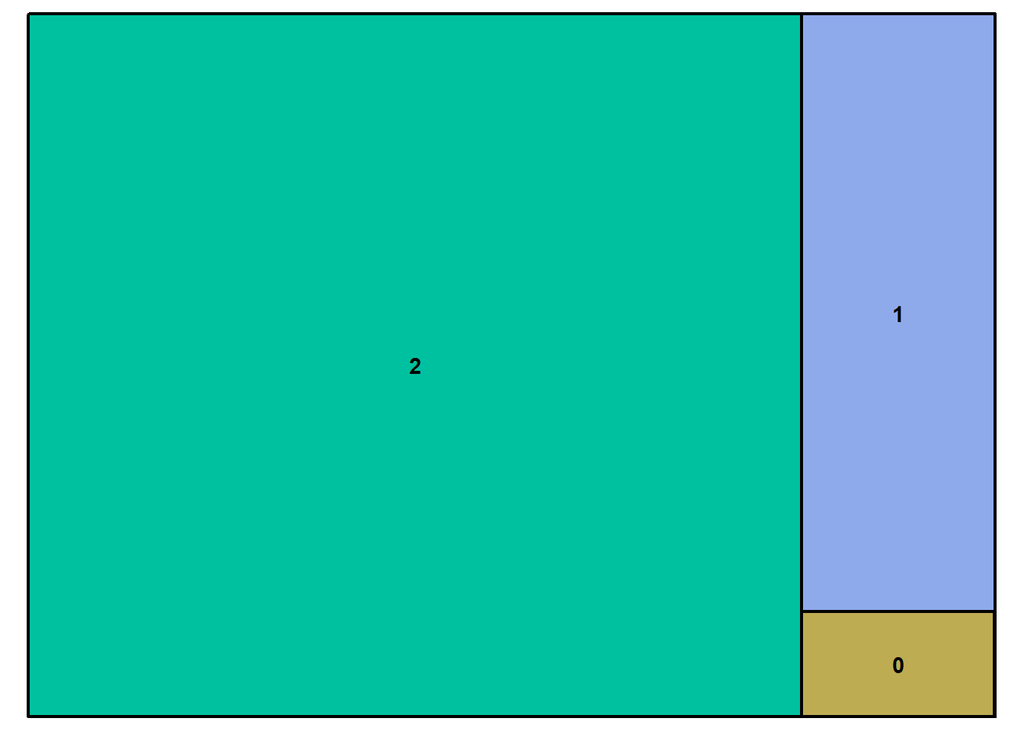

**FACTOR LEVELS**:

[output not shown]

#### OUTREAS

Out-of-scope reason

DATA TYPEcategorical

SUBTYPEnominal

CLASScategory

FORMATcode

MAX NCHAR1

DESCRIPTIONReason the organization is excluded from the NCCS core file.

**PREVIEW**:

```
T · F · S · N
```

**PROPERTIES**:

| STAT | VAL | PER |
| --- | --- | --- |
| Rows | 25,000 |  |
| Distinct | 5 | (0.0%) |
| Missing/NA | 24,961 | (99.8%) |

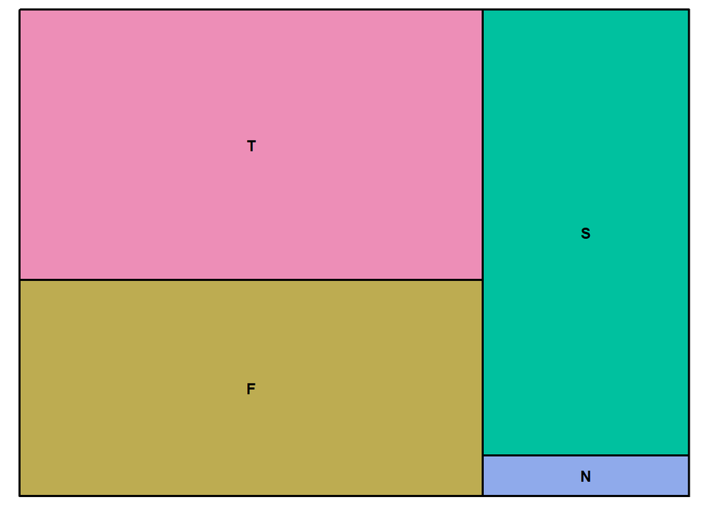

**FACTOR LEVELS**:

| Frequency | (%) | Label | Meaning |
| --- | --- | --- | --- |
| 15 | (0.1%) | T | Terminated / defunct |
| 12 | (0.0%) | F | Foreign / non-US |
| 11 | (0.0%) | S | Small (below filing threshold) |
| 1 | (0.0%) | N | Not a reporting public charity |

#### F9_00_TAX_PERIOD_BEGIN_DATE

Tax period begin

DATA TYPEcategorical

SUBTYPEnominal

CLASSreporting_period

FORMATcode

MAX NCHAR5

DESCRIPTIONFiscal-period start code for the reporting year.

**PREVIEW**:

```
20190 · 20189 · 20180 · 20199 · 20179 · 20170 · 20169 · 20191
20200 · 20181 · 20171 · 20201
```

**PROPERTIES**:

| STAT | VAL | PER |
| --- | --- | --- |
| Rows | 25,000 |  |
| Distinct | 12 | (0.0%) |

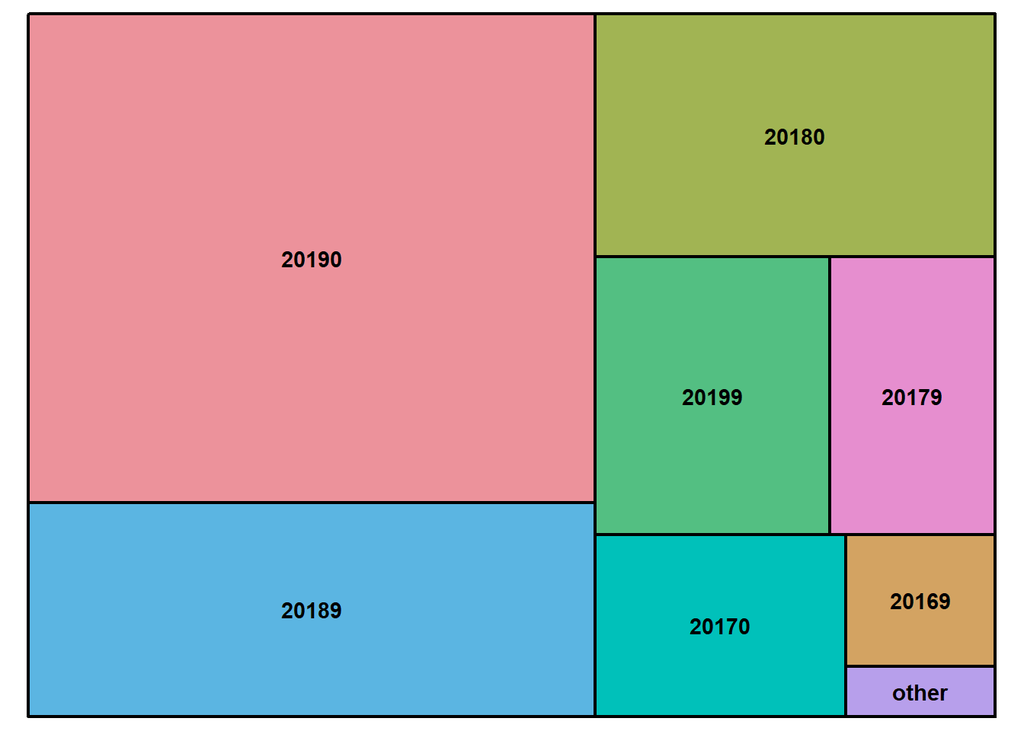

**FACTOR LEVELS**:

| Frequency | (%) | Label |
| --- | --- | --- |
| 10,190 | (40.8%) | 20190 |
| 4,460 | (17.8%) | 20189 |
| 3,580 | (14.3%) | 20180 |
| 2,402 | (9.6%) | 20199 |
| 1,686 | (6.7%) | 20179 |
| 1,680 | (6.7%) | 20170 |
| 728 | (2.9%) | 20169 |
| 123 | (0.5%) | 20191 |
| 79 | (0.3%) | 20200 |
| 46 | (0.2%) | 20181 |
| 25 | (0.1%) | 20171 |
| 1 | (0.0%) | 20201 |

#### F9_00_TAX_ACCPER

Accounting period

DATA TYPEcategorical

SUBTYPEordinal

CLASSmonth_of_year

FORMATcode

MAX NCHAR2

DESCRIPTIONMonth in which the organization’s fiscal year ends.

**PREVIEW**:

```
12 · 6 · 9 · 3 · 5 · 8 · 4 · 10 · 7 · 11 · 2 · 1
```

**PROPERTIES**:

| STAT | VAL | PER |
| --- | --- | --- |
| Rows | 25,000 |  |
| Distinct | 12 | (0.0%) |

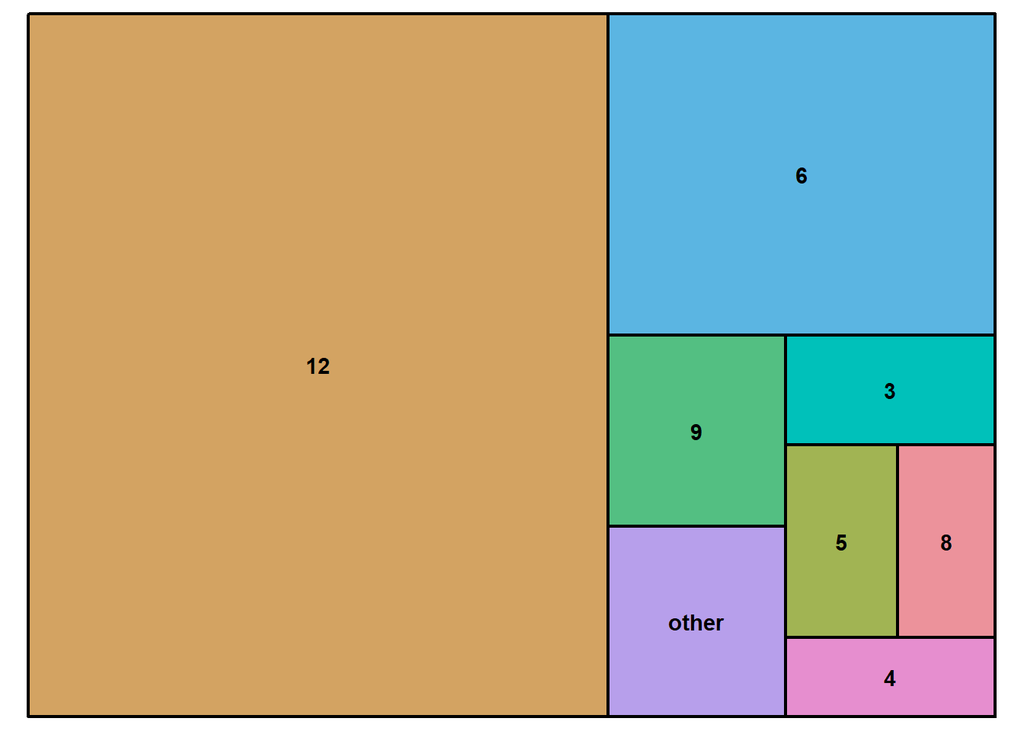

**FACTOR LEVELS**:

| Frequency | (%) | Label | Meaning |
| --- | --- | --- | --- |
| 14,987 | (59.9%) | 12 | December |
| 4,578 | (18.3%) | 6 | June |
| 1,251 | (5.0%) | 9 | September |
| 849 | (3.4%) | 3 | March |
| 796 | (3.2%) | 5 | May |
| 688 | (2.8%) | 8 | August |
| 609 | (2.4%) | 4 | April |
| 425 | (1.7%) | 10 | October |
| 349 | (1.4%) | 7 | July |
| 195 | (0.8%) | 11 | November |
| 156 | (0.6%) | 2 | February |
| 117 | (0.5%) | 1 | January |

## Numeric

#### BMF_ACTIV1

BMF activity code

DATA TYPEnumber

MAX NCHAR 3

DESCRIPTIONPrimary IRS Business Master File activity code (legacy numeric code).

**PREVIEW**:

```
0 · 263 · 200 · 907 · 36 · 279 · 205 · 319 · 59 · 318 · 407 · 520
900 · 265 · 264 · 280 · 260 · 250 · 999 · 920 · 30 · 912 · 261 · 230
65 · 998 · 229 · 317 · 201 · 403 · 908 · 288 · 911 · 399 · 286 · 161
922 · 281 · 350 · 123 · 287 · 382 · 401 · 921 · 34 · 119 · 408 · 602
```

**PROPERTIES**:

| STAT | VAL | PER |
| --- | --- | --- |
| Rows | 25,000 |  |
| Distinct | 230 | (0.9%) |
| Missing/NA | 1,887 | (7.5%) |
| Zero | 5,807 | (23.2%) |

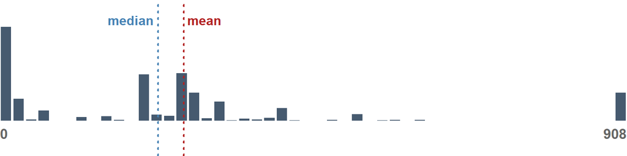

**STATS**:

| MIN | MAX | MEAN | Q05 | Q25 | Q50 | Q75 | Q95 |
| --- | --- | --- | --- | --- | --- | --- | --- |
| 0 | 999 | 266.51 | 0 | 0 | 229 | 318 | 908 |

**DISTRIBUTION SHAPE**:

| stat | num | interpretation |
| --- | --- | --- |
| Skew | 1.32 | HIGH |
| Kurtosis | 0.86 | LOW |

#### F9_08_REV_TOT_TOT

Total revenue

DATA TYPEnumber

SUBTYPEcontinuous

CLASScurrency

FORMATcurrency

MAX NCHAR10

DESCRIPTIONTotal revenue for the year (Form 990, Part VIII).

**PREVIEW**:

```
0 · 100 · 1000 · 250000 · 2000 · 2250 · 50 · 200 · 45000 · 4 · 1500
5000 · 6000 · 8800 · 25000 · 25500 · 75000 · 1e+05 · 101225 · 1 · 3
8 · 9 · 101 · 575 · 600 · 1200 · 1800 · 2074 · 2400 · 4125 · 5400
6800 · 9465 · 9500 · 10000 · 15000 · 19611 · 20000 · 20649 · 26873
```

**PROPERTIES**:

| STAT | VAL | PER |
| --- | --- | --- |
| Rows | 25,000 |  |
| Distinct | 23,817 | (95.3%) |
| Zero | 413 | (1.7%) |

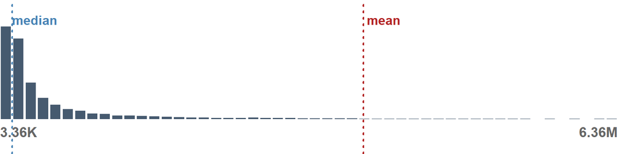

**STATS**:

| MIN | MAX | MEAN | Q05 | Q25 | Q50 | Q75 | Q95 |
| --- | --- | --- | --- | --- | --- | --- | --- |
| -61,467,591 | 4,178,522,311 | 3,740,777 | 3,359.8 | 51,012.5 | 130,545 | 441,954.5 | 6,355,357 |

**DISTRIBUTION SHAPE**:

| stat | num | interpretation |
| --- | --- | --- |
| Skew | 44.03 | HIGH |
| Kurtosis | 2,557.92 | HIGH |

#### F9_10_ASSET_TOT_BOY

Total assets (BOY)

DATA TYPEnumber

SUBTYPEcontinuous

CLASScurrency

FORMATcurrency

MAX NCHAR11

DESCRIPTIONTotal assets at the beginning of the year (Form 990, Part X).

**PREVIEW**:

```
0 · 1 · 300 · 161 · 1593 · 10571 · 20855 · 21915 · 43506 · 49481 · 2
97 · 212 · 219 · 343 · 388 · 500 · 718 · 1000 · 1020 · 1222 · 1535
1547 · 1607 · 1642 · 2155 · 2745 · 3068 · 3073 · 3087 · 3708 · 4412
4414 · 4612 · 5251 · 5501 · 5619 · 5761 · 6141 · 6267 · 6812 · 6865
```

**PROPERTIES**:

| STAT | VAL | PER |
| --- | --- | --- |
| Rows | 25,000 |  |
| Distinct | 20,195 | (80.8%) |
| Missing/NA | 1,377 | (5.5%) |
| Zero | 3,011 | (12.0%) |

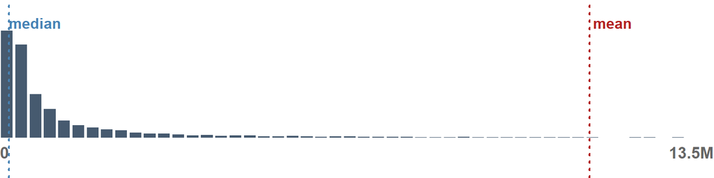

**STATS**:

| MIN | MAX | MEAN | Q05 | Q25 | Q50 | Q75 | Q95 |
| --- | --- | --- | --- | --- | --- | --- | --- |
| -69,049 | 11,226,543,829 | 11,116,959 | 0 | 31,558.5 | 169,734 | 729,844.5 | 13,488,117 |

**DISTRIBUTION SHAPE**:

| stat | num | interpretation |
| --- | --- | --- |
| Skew | 41.82 | HIGH |
| Kurtosis | 2,117.75 | HIGH |

#### F9_10_ASSET_TOT_EOY

Total assets (EOY)

DATA TYPEnumber

SUBTYPEcontinuous

CLASScurrency

FORMATcurrency

MAX NCHAR11

DESCRIPTIONTotal assets at the end of the year (Form 990, Part X).

**PREVIEW**:

```
1 · 0 · 100 · 1000 · 15000 · 21 · 480 · 529 · 680 · 1257 · 1374
1932 · 2000 · 2076 · 2280 · 2680 · 2965 · 3000 · 10000 · 24731
24753 · 37977 · 40760 · 25 · 30 · 39 · 90 · 99 · 140 · 149 · 200
212 · 230 · 248 · 249 · 281 · 314 · 340 · 415 · 459 · 478 · 627
```

**PROPERTIES**:

| STAT | VAL | PER |
| --- | --- | --- |
| Rows | 25,000 |  |
| Distinct | 24,122 | (96.5%) |
| Zero | 110 | (0.4%) |

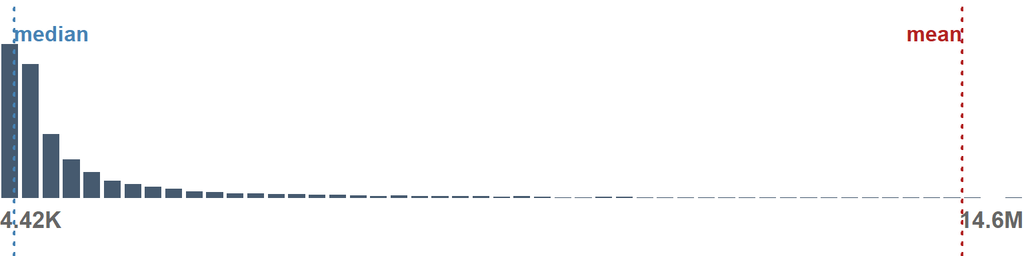

**STATS**:

| MIN | MAX | MEAN | Q05 | Q25 | Q50 | Q75 | Q95 |
| --- | --- | --- | --- | --- | --- | --- | --- |
| -1,119,570 | 38,468,314,242 | 13,755,826 | 4,421.45 | 55,668.25 | 212,649 | 837,286 | 14,639,755 |

**DISTRIBUTION SHAPE**:

| stat | num | interpretation |
| --- | --- | --- |
| Skew | 85.67 | HIGH |
| Kurtosis | 9,676.68 | HIGH |

#### F9_10_NAFB_TOT_BOY

Net assets (BOY)

DATA TYPEnumber

SUBTYPEcontinuous

CLASScurrency

FORMATcurrency

MAX NCHAR10

DESCRIPTIONNet assets or fund balances at the beginning of the year.

**PREVIEW**:

```
0 · 300 · 1593 · 8311 · 20855 · 24587 · 29596 · 56803 · -21474
-6426 · -989 · -826 · 97 · 161 · 212 · 334 · 388 · 500 · 718 · 1000
1020 · 1547 · 1642 · 2745 · 2870 · 3068 · 3073 · 3087 · 3306 · 3554
3708 · 4412 · 4414 · 4612 · 4772 · 5318 · 5501 · 5619 · 6141 · 6267
```

**PROPERTIES**:

| STAT | VAL | PER |
| --- | --- | --- |
| Rows | 25,000 |  |
| Distinct | 20,145 | (80.6%) |
| Missing/NA | 4,344 | (17.4%) |
| Zero | 203 | (0.8%) |

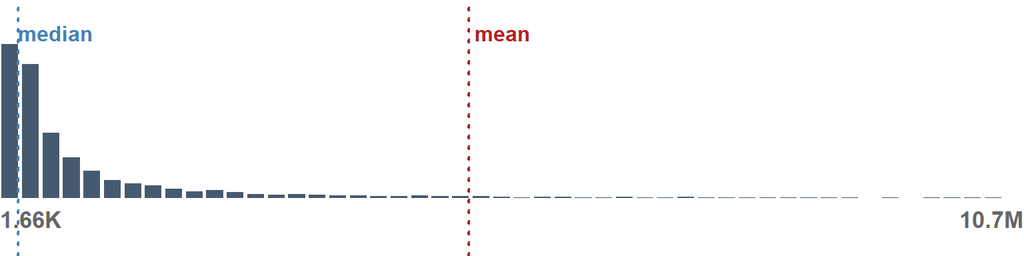

**STATS**:

| MIN | MAX | MEAN | Q05 | Q25 | Q50 | Q75 | Q95 |
| --- | --- | --- | --- | --- | --- | --- | --- |
| -333,005,908 | 6,323,689,488 | 4,921,982 | 1,659.5 | 52,689.5 | 192,629.5 | 720,262.5 | 10,744,071 |

**DISTRIBUTION SHAPE**:

| stat | num | interpretation |
| --- | --- | --- |
| Skew | 61.69 | HIGH |
| Kurtosis | 5,412.22 | HIGH |

#### F9_09_EXP_TOT_TOT

Total expenses

DATA TYPEnumber

SUBTYPEcontinuous

CLASScurrency

FORMATcurrency

MAX NCHAR10

DESCRIPTIONTotal functional expenses for the year (Form 990, Part IX).

**PREVIEW**:

```
0 · 100 · 1000 · 10 · 50 · 600 · 4056 · 7500 · 25 · 200 · 400 · 539
786 · 1140 · 5000 · 10000 · 11085 · 13669 · 16927 · 16993 · 19327
28348 · 36264 · 40526 · 45638 · 48401 · 50154 · 60157 · 62391
80427 · 83368 · 83437 · 105341 · 153299 · 41 · 60 · 129 · 130 · 143
```

**PROPERTIES**:

| STAT | VAL | PER |
| --- | --- | --- |
| Rows | 25,000 |  |
| Distinct | 23,740 | (95.0%) |
| Zero | 489 | (2.0%) |

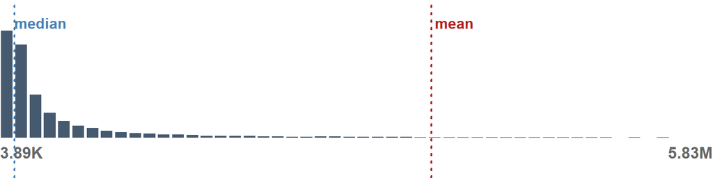

**STATS**:

| MIN | MAX | MEAN | Q05 | Q25 | Q50 | Q75 | Q95 |
| --- | --- | --- | --- | --- | --- | --- | --- |
| -11,719 | 4,256,605,589 | 3,531,376 | 3,886.95 | 46,845 | 121,792.5 | 411,837.2 | 5,832,724 |

**DISTRIBUTION SHAPE**:

| stat | num | interpretation |
| --- | --- | --- |
| Skew | 46.21 | HIGH |
| Kurtosis | 2,819.69 | HIGH |

#### F9_01_EXP_TOT_PY

Total expenses (prior year)

DATA TYPEnumber

SUBTYPEcontinuous

CLASScurrency

FORMATcurrency

MAX NCHAR10

DESCRIPTIONTotal expenses reported for the prior year.

**PREVIEW**:

```
0 · 10 · 36 · 600 · 1450 · 2279 · 3200 · 4742 · 8214 · 14221 · 25853
32965 · 43809 · 44039 · 44951 · 54368 · 55199 · 56378 · 78821
126182 · 20 · 400 · 656 · 736 · 827 · 859 · 1220 · 1540 · 1938
2206 · 2487 · 2489 · 2505 · 2831 · 3371 · 3400 · 3433 · 3552 · 4500
```

**PROPERTIES**:

| STAT | VAL | PER |
| --- | --- | --- |
| Rows | 25,000 |  |
| Distinct | 19,931 | (79.7%) |
| Missing/NA | 1,377 | (5.5%) |
| Zero | 3,257 | (13.0%) |

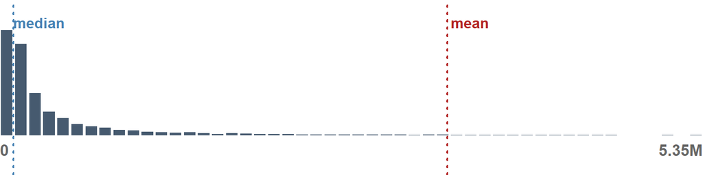

**STATS**:

[output not shown]

**DISTRIBUTION SHAPE**:

| stat | num | interpretation |
| --- | --- | --- |
| Skew | 48.26 | HIGH |
| Kurtosis | 3,041.41 | HIGH |

## Character

#### F9_00_ORG_NAME_L1

Organization name

DATA TYPEtext

SUBTYPEphrase

CLASSorganization_name

FORMATplain

MAX NCHAR97

DESCRIPTIONLegal name of the filing organization (Form 990, header).

**PREVIEW**:

```
AMERICAN LEGION · ROTARY INTERNATIONAL
BENEVOLENT & PROTECTIVE ORDER OF ELKS OF THE USA
VETERANS OF FOREIGN WARS OF THE UNITED STATES DE
INTERNATIONAL ASSOCIATION OF LIONS CLUBS · KNIGHTS OF COLUMBUS
```

**PROPERTIES**:

| STAT | VAL | PER |
| --- | --- | --- |
| Rows | 25,000 |  |
| Distinct | 17,455 | (69.8%) |
| Missing/NA | 1,378 | (5.5%) |

[figure not shown]

**MOST COMMON VALUES**:

[output not shown]

#### F0_00_ORG_CONTACT

Contact person

DATA TYPEtext

SUBTYPEphrase

CLASSperson_name

FORMATplain

MAX NCHAR33

DESCRIPTIONName of the organization’s principal officer or contact.

**PREVIEW**:

```
TREASURER · FINANCIAL SECRETARY · THE ORGANIZATION
SORORITY SOLUTIONS · WORTHY SECRETARY · COMMERCE · PEO TREASURER
PRESIDENT · SECRETARY · THE BANK OF NEW YORK MELLON · COMMANDER
SECRETARY TREASURER · AGRECORDS · SCIARABBA WALKER · AIPSO
```

**PROPERTIES**:

| STAT | VAL | PER |
| --- | --- | --- |
| Rows | 25,000 |  |
| Distinct | 10,990 | (44.0%) |
| Missing/NA | 13,392 | (53.6%) |

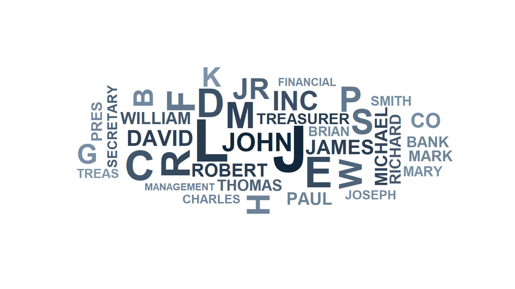

**MOST COMMON VALUES**:

| Value | Frequency | (%) |
| --- | --- | --- |
| TREASURER | 67 | (0.3%) |
| FINANCIAL SECRETARY | 66 | (0.3%) |
| THE ORGANIZATION | 44 | (0.2%) |
| SORORITY SOLUTIONS | 27 | (0.1%) |
| WORTHY SECRETARY | 24 | (0.1%) |
| COMMERCE | 18 | (0.1%) |

#### F9_00_ORG_ADDR_L1

Street address

DATA TYPEtext

SUBTYPEline

CLASSaddress

FORMATplain

MAX NCHAR35

DESCRIPTIONMailing street address of the organization.

**PREVIEW**:

```
9717 ELK GROVE FLORIN RD STE B · 1154 TOWN AND COUNTRY COMMONS DR
PO BOX 1 · PO BOX 2 · PO BOX 5 · PO BOX 66 · PO BOX 86 · PO BOX 111
PO BOX 217 · PO BOX 26 · PO BOX 6 · 695 PRO MED LN STE 300
PO BOX 187 · PO BOX 123 · PO BOX 40 · PO BOX 535007 · PO BOX 8
```

**PROPERTIES**:

| STAT | VAL | PER |
| --- | --- | --- |
| Rows | 25,000 |  |
| Distinct | 18,785 | (75.1%) |
| Missing/NA | 1,378 | (5.5%) |

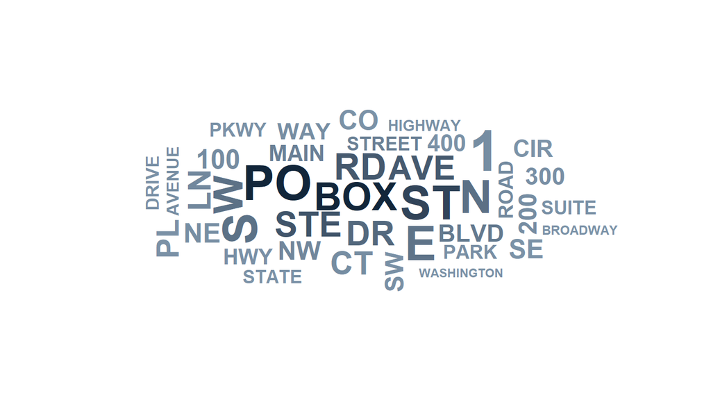

**MOST COMMON VALUES**:

| Value | Frequency | (%) |
| --- | --- | --- |
| 9717 ELK GROVE FLORIN RD STE B | 37 | (0.1%) |
| 1154 TOWN AND COUNTRY COMMONS DR | 23 | (0.1%) |
| PO BOX 1 | 20 | (0.1%) |
| PO BOX 2 | 19 | (0.1%) |
| PO BOX 5 | 19 | (0.1%) |
| PO BOX 66 | 18 | (0.1%) |

#### F9_00_ORG_ADDR_CITY

City

DATA TYPEtext

SUBTYPEphrase

CLASSplace_name

FORMATplain

MAX NCHAR22

DESCRIPTIONCity of the organization’s mailing address.

**PREVIEW**:

```
WASHINGTON · NEW YORK · CHICAGO · HOUSTON · COLUMBUS · INDIANAPOLIS
SPRINGFIELD · SACRAMENTO · AUSTIN · LOS ANGELES · PITTSBURGH
ATLANTA · DALLAS · SAN FRANCISCO · SAN DIEGO · SEATTLE · PORTLAND
COLUMBIA · ALEXANDRIA · PHILADELPHIA · DENVER · SAINT LOUIS
```

**PROPERTIES**:

| STAT | VAL | PER |
| --- | --- | --- |
| Rows | 25,000 |  |
| Distinct | 5,986 | (23.9%) |
| Missing/NA | 1,378 | (5.5%) |

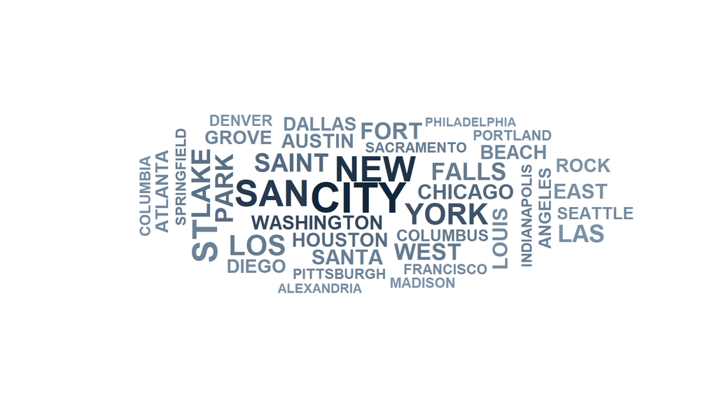

**MOST COMMON VALUES**:

| Value | Frequency | (%) |
| --- | --- | --- |
| WASHINGTON | 331 | (1.3%) |
| NEW YORK | 262 | (1.0%) |
| CHICAGO | 187 | (0.7%) |
| HOUSTON | 184 | (0.7%) |
| COLUMBUS | 143 | (0.6%) |
| INDIANAPOLIS | 133 | (0.5%) |

#### NTEEFINAL

NTEE code

DATA TYPEtext

SUBTYPEtoken

CLASSclassification_code

FORMATcode

MAX NCHAR 5

DESCRIPTIONFull National Taxonomy of Exempt Entities code assigned to the organization.

**PREVIEW**:

```
S41 · J40 · W30 · S80 · N50 · M24 · B83 · W80 · N60 · Y42 · Y50
Y41 · K28 · S20 · Y43 · S47 · B03 · L50 · W61 · N61 · Y40 · S03
Y20 · S30 · S01 · S40 · G90 · I03 · I0360 · N52 · S99 · A23 · S22
N67 · N6A · E11 · N68 · K20 · N69 · L99 · S46 · N32 · U42 · S21
```

**PROPERTIES**:

| STAT | VAL | PER |
| --- | --- | --- |
| Rows | 25,000 |  |
| Distinct | 654 | (2.6%) |
| Missing/NA | 1,497 | (6.0%) |

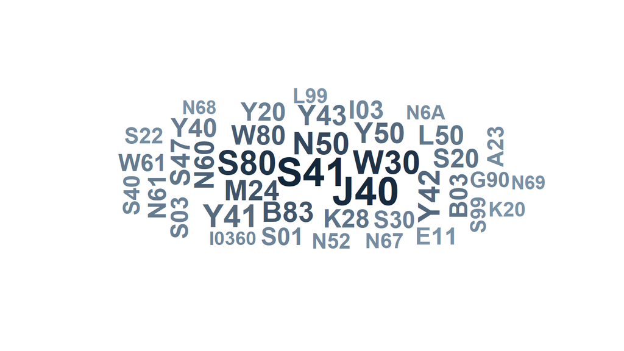

**MOST COMMON VALUES**:

| Value | Frequency | (%) |
| --- | --- | --- |
| S41 | 1947 | (7.8%) |
| J40 | 1815 | (7.3%) |
| W30 | 1582 | (6.3%) |
| S80 | 1515 | (6.1%) |
| N50 | 1088 | (4.4%) |
| M24 | 810 | (3.2%) |

## Identifier

#### EIN

Employer Identification Number

DATA TYPEidentifier

SUBTYPEnumeric_id

CLASSadministrative_id

FORMATplain

MAX NCHAR 9

DESCRIPTIONIRS-assigned 9-digit taxpayer ID; the unique key for the organization.

**PREVIEW**:

```
10100593 · 10218055 · 10220588 · 10266289 · 10273431 · 10286963
10440702 · 10468398 · 10523313 · 10524078 · 10573723 · 10715375
10744517 · 10815981 · 10852125 · 10874048 · 10961458 · 16011483
16012302 · 16019950 · 16022337 · 16123853 · 20172119 · 20187390
```

**PROPERTIES**:

| STAT | VAL | PER |
| --- | --- | --- |
| Rows | 25,000 |  |
| Distinct | 24,794 | (99.2%) |

**MOST COMMON VALUES**:

| Value | Frequency | (%) |
| --- | --- | --- |
| 10100593 | 2 | (0.0%) |
| 10218055 | 2 | (0.0%) |
| 10220588 | 2 | (0.0%) |
| 10266289 | 2 | (0.0%) |
| 10273431 | 2 | (0.0%) |
| 10286963 | 2 | (0.0%) |

#### COUNTY_FIPS

County (FIPS)

DATA TYPEidentifier

SUBTYPEnumeric_id

CLASSgeographic_id

FORMATplain

MAX NCHAR 5

DESCRIPTION5-digit Census county FIPS code of the organization’s location.

**PREVIEW**:

```
6037 · 17031 · 11001 · 36061 · 48201 · 53033 · 6067 · 42003 · 39049
6073 · 6059 · 25017 · 4013 · 27053 · 48113 · 36103 · 18097 · 48453
39035 · 36059 · 6085 · 6001 · 25025 · 51059 · 9003 · 36119 · 13121
26163 · 19153 · 26125 · 6075 · 9001 · 48439 · 42101 · 9009 · 17043
```

**PROPERTIES**:

| STAT | VAL | PER |
| --- | --- | --- |
| Rows | 25,000 |  |
| Distinct | 2,411 | (9.6%) |
| Missing/NA | 2,389 | (9.6%) |

**MOST COMMON VALUES**:

| Value | Frequency | (%) |
| --- | --- | --- |
| 6037 | 402 | (1.6%) |
| 17031 | 339 | (1.4%) |
| 11001 | 294 | (1.2%) |
| 36061 | 243 | (1.0%) |
| 48201 | 213 | (0.9%) |
| 53033 | 186 | (0.7%) |

#### CEO_CENSUSTRACT

Census tract (GEOID)

DATA TYPEidentifier

SUBTYPEnumeric_id

CLASSgeographic_id

FORMATplain

MAX NCHAR11

DESCRIPTION11-digit Census tract identifier of the organization’s location.

**PREVIEW**:

```
11001010700 · 48201531700 · 6037294421 · 11001010100 · 11001005800
17031839100 · 6067001101 · 6073020809 · 48113020300 · 11001005900
18097391000 · 4013941000 · 51510201900 · 6085512100 · 36061016100
42003020100 · 48453000102 · 48453001100 · 6075011700 · 11001006202
```

**PROPERTIES**:

| STAT | VAL | PER |
| --- | --- | --- |
| Rows | 25,000 |  |
| Distinct | 14,265 | (57.1%) |
| Missing/NA | 3,110 | (12.4%) |

**MOST COMMON VALUES**:

| Value | Frequency | (%) |
| --- | --- | --- |
| 11001010700 | 69 | (0.3%) |
| 48201531700 | 63 | (0.3%) |
| 6037294421 | 36 | (0.1%) |
| 11001010100 | 34 | (0.1%) |
| 11001005800 | 32 | (0.1%) |
| 17031839100 | 31 | (0.1%) |

## Temporal

#### F9_00_TAX_PERIOD_END_DATE

Tax period end

DATA TYPEtemporal

SUBTYPEnominal

CLASSreporting_period

FORMATcode

UNITmonth

MAX NCHAR6

DESCRIPTIONYear and month (YYYYMM) the reporting tax period ended.

**PREVIEW**:

```
201912 · 201812 · 201906 · 201712 · 202006 · 201806 · 201909
201908 · 201706 · 201903 · 202003 · 201905 · 201904 · 201910
202005 · 201809 · 202004 · 201907 · 201805 · 201808 · 201911
201709 · 201803 · 201804 · 201810 · 202007 · 202008 · 202009
```

**PROPERTIES**:

| STAT | VAL | PER |
| --- | --- | --- |
| Rows | 25,000 |  |
| Distinct | 47 | (0.2%) |

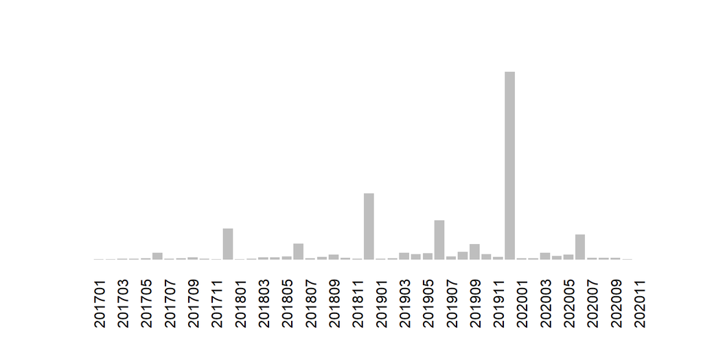

#### F9_00_TAX_PERIOD_END_DATE_PY

Tax period end (prior year)

DATA TYPEtemporal

SUBTYPEnominal

CLASSreporting_period

FORMATcode

UNITmonth

MAX NCHAR6

DESCRIPTIONYear and month the prior-year tax period ended.

**PREVIEW**:

```
201812 · 201712 · 201806 · 201906 · 201809 · 201706 · 201612
201808 · 201803 · 201903 · 201805 · 201810 · 201804 · 201905
201709 · 201606 · 201904 · 201807 · 201811 · 201708 · 201705
201710 · 201704 · 201901 · 201907 · 201703 · 201902 · 201802
```

**PROPERTIES**:

| STAT | VAL | PER |
| --- | --- | --- |
| Rows | 25,000 |  |
| Distinct | 47 | (0.2%) |
| Missing/NA | 4,344 | (17.4%) |

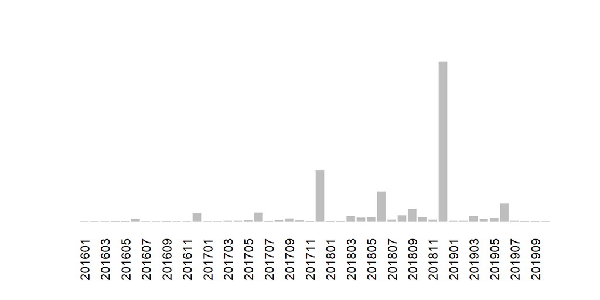